# Two-patch deterministic and stochastic models for Ebola spillover

This report contains all code for numerical implementation of the two-patch deterministic and stochastic models presented in the main text of the manuscript entitled: “Theory of infectious disease spillover at an ecological boundary: Impacts of seasonality and cross boundary movement”.

In this markdown document, we call two external functions:

1. Two_Patch_Ebola_ODE_Model.R, defining the deterministic model equations
2. CTMC_Ebola_V02.R, representing a single run for the stochastic simulation model

# Two-patch model - without seasonality without movement

In the following, we run the simulation for one year

# FIGURE 2

Plotting the baseline results: without seasonality without movement - one year

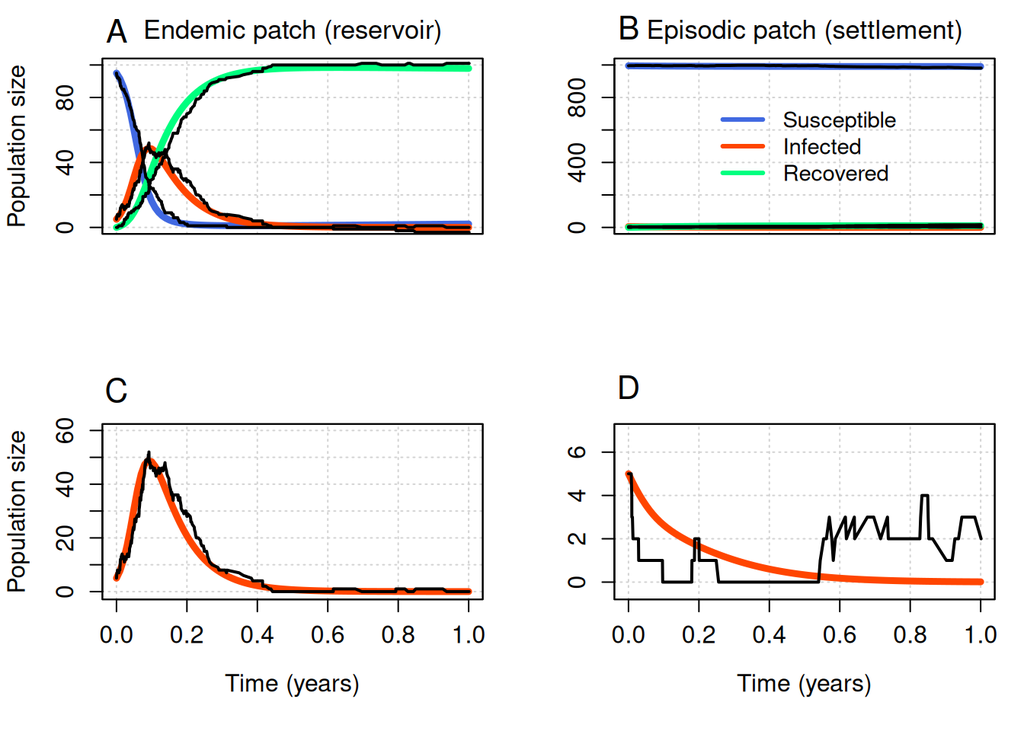

# Two-patch model - with seasonality with movement – ONE YEAR

Here we run the simulation for one year.

# Figure not included in the manuscript

Plotting the results: with seasonality with movement – one year

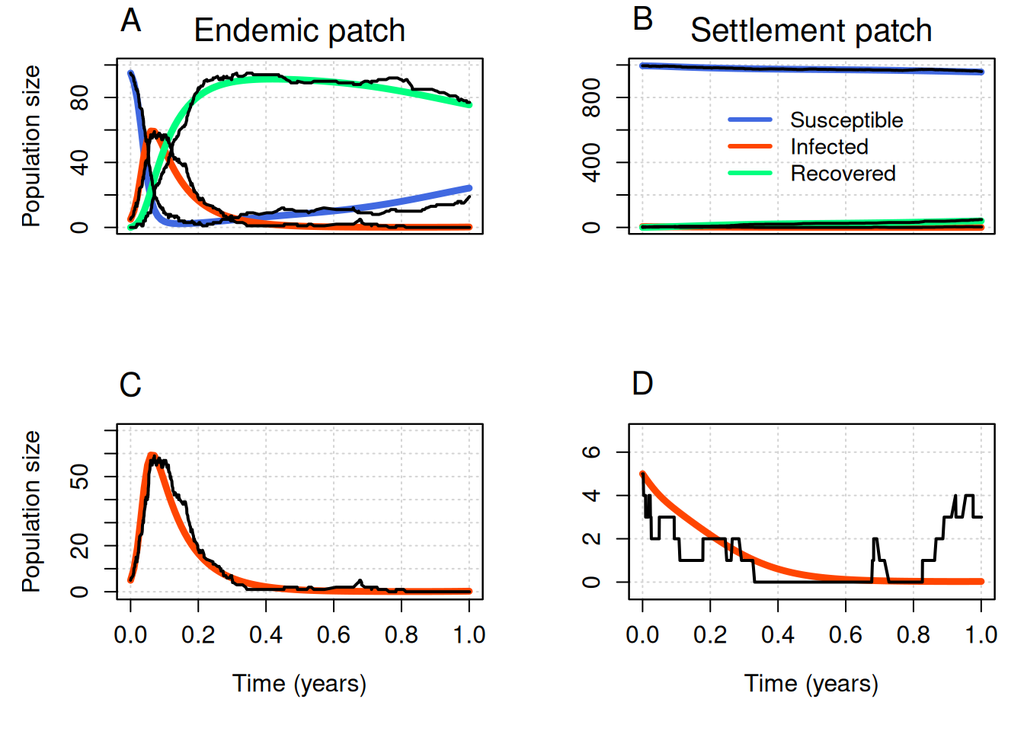

# Two-patch model - without seasonality with movement

In the following, we run the simulation for 10 years

In the stochastic model, extinction occurs as a result of fluctuations near the time axis. This occurs when we run the simulation for long periods of time (more than one year). To avoid extinction, we added a constant to the transmission rate in the reservoir patch. A value of 15 was added in the CTMC model before we run the simulation.

# FIGURE 3

Plotting the results: without seasonality with movement – 10 years

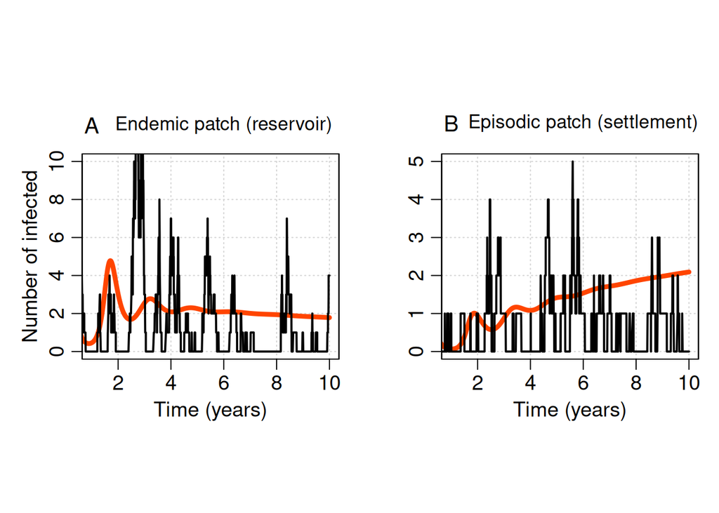

# Figure A1

Plotting the results: without seasonality with movement – 10 years

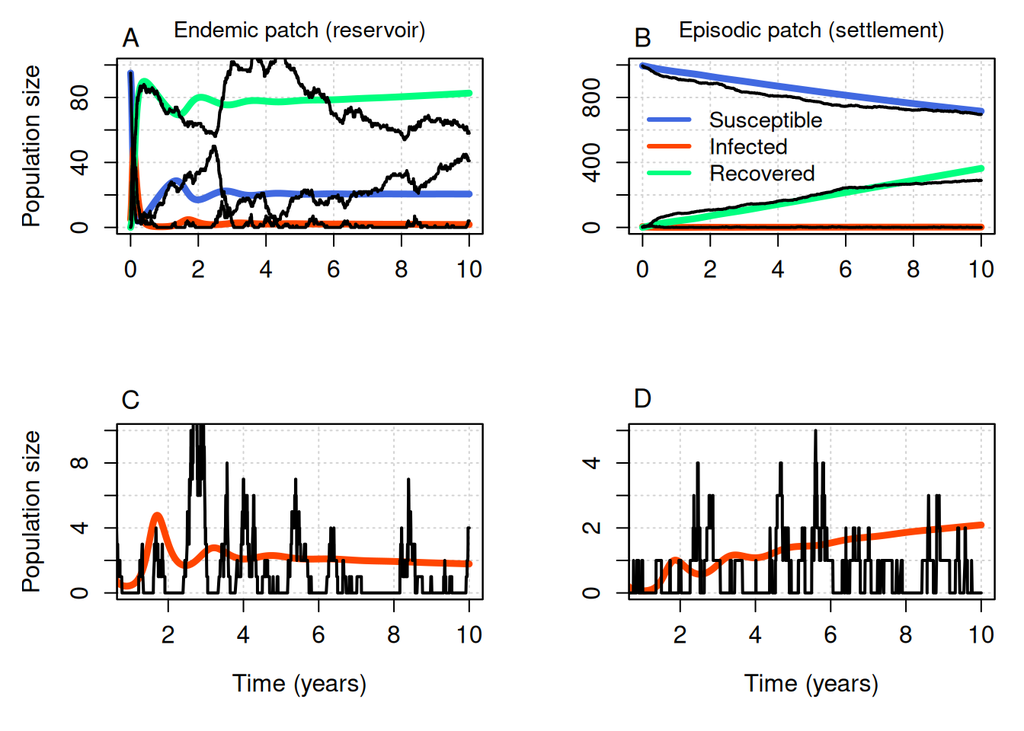

Now we add seasonality

# FIGURE 4

Plotting the results: with seasonality with movement – 10 years

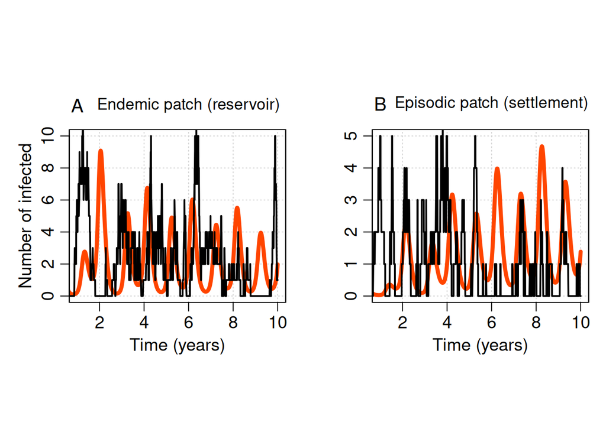

# Figure A2

Plotting the results: with seasonality with movement – 10 years

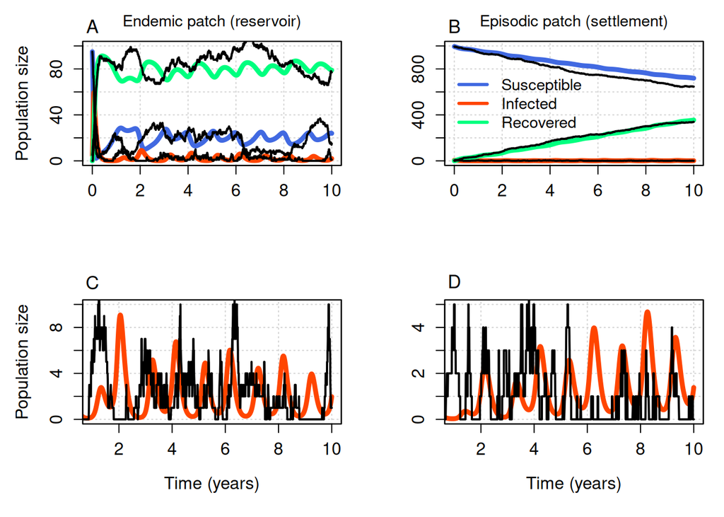

# Trajectories vs seasonality amplitude – 100 years

With seasonality and movement